# Practical Machine Learning - Course Project

Dillon Jaghory

5/27/2020

# Introduction and Setup

Using devices such as Jawbone Up, Nike FuelBand, and Fitbit it is now possible to collect a large amount of data about personal activity relatively inexpensively. One thing that people regularly do is quantify how much of a particular activity they do, but they rarely quantify how well they do it. In this project, your goal will be to use data from accelerometers on the belt, forearm, arm, and dumbell of 6 participants. They were asked to perform barbell lifts correctly and incorrectly in 5 different ways.

This study will design a machine learning algorithm to predict the manner in which participants exercised. The manner in which participants exercised is quantified by the “classe” variable.

The data for this project comes from: http://groupware.les.inf.puc-rio.br/har

**Obtaining the data and setting up the files**

```r
# Library Setup
library(caret)
library(rpart)
library(ggplot2)
library(DataExplorer)
library(corrplot)
library(RColorBrewer)
library(tidyverse)
library(randomForest)
library(rattle)
library(rpart.plot)
```

```r
# File Setup
filename1 <- "training.csv"
filename2 <- "testing.csv"

## Downloading the dataset:
if (!file.exists(filename1)){
  fileURL1 <- "https://d396qusza40orc.cloudfront.net/predmachlearn/pml-training.csv"
  download.file(fileURL1, filename1, method="curl")
}

if (!file.exists(filename2)){
  fileURL2 <- "https://d396qusza40orc.cloudfront.net/predmachlearn/pml-testing.csv"
  download.file(fileURL2, filename2, method="curl")
}

training <- read.csv("training.csv")
testing <- read.csv("testing.csv")
```

**Cleaning the data**

```r
#Checking for Near-Zero Covariates and removing them
nsv <- nearZeroVar(training, names = TRUE)
all_cols <- names(training)
training <- training[ , setdiff(all_cols, nsv)]

#Cleaning out identifier columns and missing values
training <- training[, which(colMeans(!is.na(training)) > 0.5)]
training <- subset(training, select = -c(1:2))
training <- subset(training, select = -c(3))

#Data partition
inTrain <- createDataPartition(training$classe, p = .8,
                                  list = FALSE)
trainSet <- training[inTrain,]
validationSet  <- training[-inTrain,]
```

# Exploratory Analysis

A cursory look at the data shows that exercise type A occurs most frequently, while the other kinds of exercise occur at roughly the same rate.

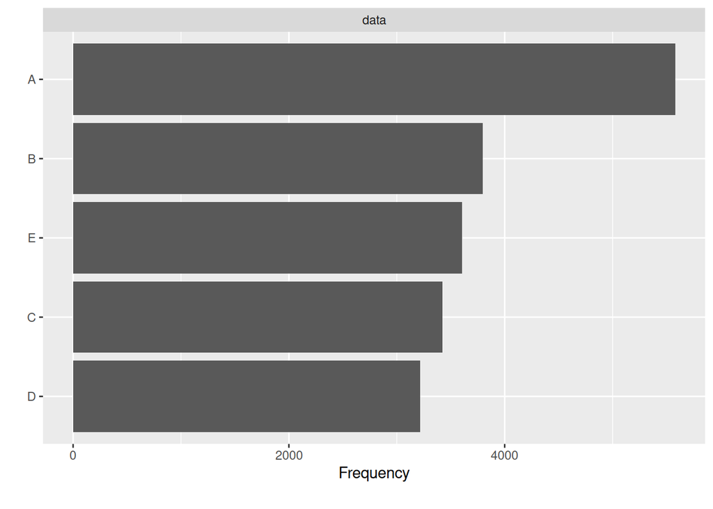

```r
#Frequency of each exercise category
plot_bar(training$classe)
```

Using the corrplot library, I construct a colorful correlation matrix. Positive correlations are in blue whereas negative correlations are in red. The legend on the right can be used to ascertain the specific degree of correlation.

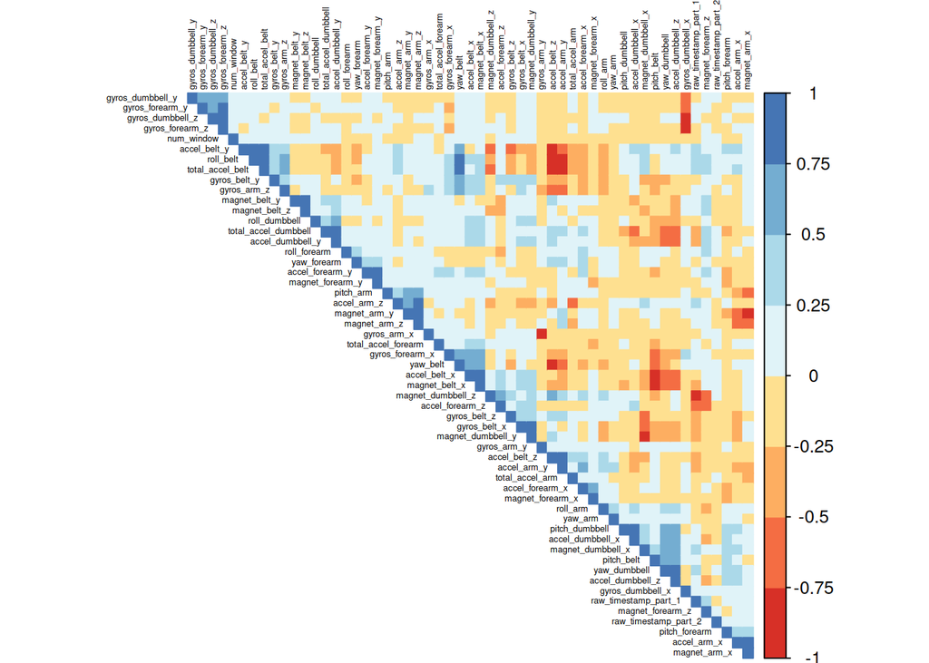

```r
#Correlation analysis
#classe column must be removed first since it is not numeric
train_cor <- training
train_cor <- subset(train_cor, select = -c(classe))
train_cor <-cor(train_cor)
corrplot(train_cor, order="hclust", type = "upper", method = "color", tl.cex = 0.4,
         tl.col = "black", col=brewer.pal(n=8, name="RdYlBu"))
```

# Model Construction

## First Model: Decision Tree

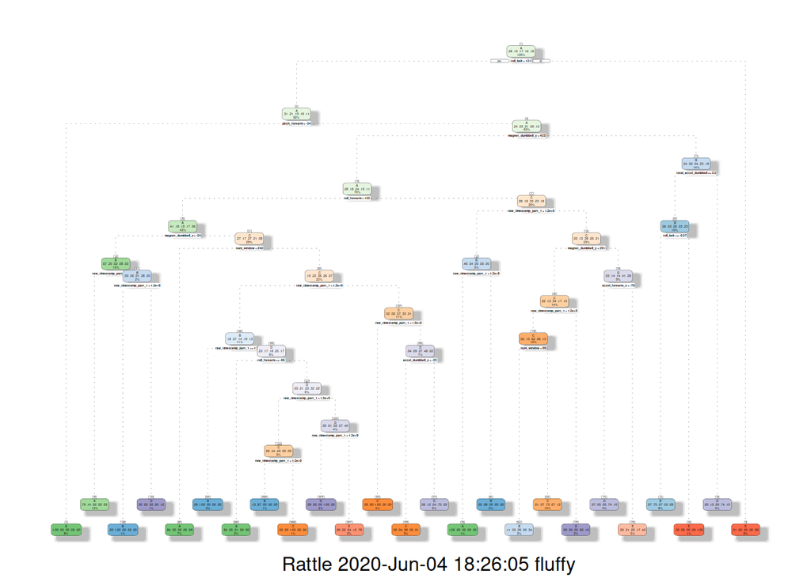

```r
set.seed(123)

dt_fit <- rpart(classe~., data = trainSet, method = 'class')
fancyRpartPlot(dt_fit)
```

## Second Model: Random Forest

```r
set.seed(123)

rf_fit <- randomForest(classe ~ ., data=trainSet, ntree=100, mtry=7, importance=TRUE)
rf_fit
```

```
##
## Call:
##  randomForest(formula = classe ~ ., data = trainSet, ntree = 100,      mtry = 7, importance = TRUE)
##                Type of random forest: classification
##                      Number of trees: 100
## No. of variables tried at each split: 7
##
##         OOB estimate of  error rate: 0.16%
## Confusion matrix:
##      A    B    C    D    E  class.error
## A 4464    0    0    0    0 0.0000000000
## B    2 3036    0    0    0 0.0006583278
## C    0    7 2730    1    0 0.0029218408
## D    0    0    6 2565    2 0.0031092110
## E    0    0    0    7 2879 0.0024255024
```

# Cross-Valdiation and Error Assessment

The two models will be tested against the validation set and the model with the higher level accuracy will be used to make predictions on the testing set.

```r
pred1 <- predict(dt_fit, validationSet, type = "class")
pred2 <- predict(rf_fit, newdata = validationSet)


cfmx1 <- confusionMatrix(pred1, validationSet$classe)
cfmx2 <- confusionMatrix(pred2, validationSet$classe)
```

**Statistics for the Decision Tree Fit**

```r
cfmx1$table
```

```
##           Reference
## Prediction    A    B    C    D    E
##          A 1050   78   13   19   41
##          B   34  537   20    9   56
##          C    5   25  592   53   48
##          D   21   63   16  517   65
##          E    6   56   43   45  511
```

```r
cfmx1$overall
```

```
##       Accuracy          Kappa  AccuracyLower  AccuracyUpper   AccuracyNull
##   8.174866e-01   7.686665e-01   8.050370e-01   8.294614e-01   2.844762e-01
## AccuracyPValue  McnemarPValue
##   0.000000e+00   2.298854e-19
```

**Statistics for the Random Forest Fit**

```r
cfmx2$table
```

```
##           Reference
## Prediction    A    B    C    D    E
##          A 1116    0    0    0    0
##          B    0  759    0    0    0
##          C    0    0  683    2    0
##          D    0    0    1  641    3
##          E    0    0    0    0  718
```

```r
cfmx2$overall
```

```
##       Accuracy          Kappa  AccuracyLower  AccuracyUpper   AccuracyNull
##      0.9984706      0.9980655      0.9966740      0.9994385      0.2844762
## AccuracyPValue  McnemarPValue
##      0.0000000            NaN
```

# Final Predictions and Conclusion

Using the random forest prediction model, we obtain the the final list of predictions:  
B A B A A E D B A A B C B A E E A B B B

After running these predictions through the week 4 quiz, every prediction turned out to be correct.

```r
finalPredictions <- predict(rf_fit, newdata = testing)
finalPredictions
```

```
##  1  2  3  4  5  6  7  8  9 10 11 12 13 14 15 16 17 18 19 20
##  B  A  B  A  A  E  D  B  A  A  B  C  B  A  E  E  A  B  B  B
## Levels: A B C D E
```